# Bayesian Modelling

### Posterior Predictive Model Checking

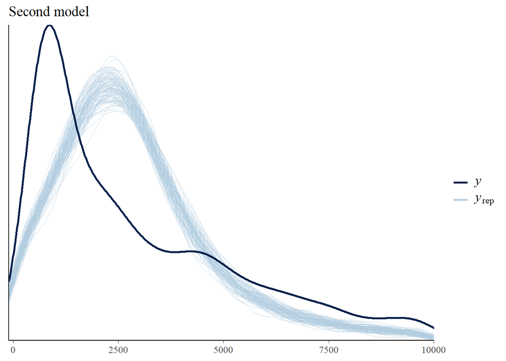

```r
mu2 <- model2_run$BUGSoutput$sims.list$mu
tau2 <- model2_run$BUGSoutput$sims.list$tau
k2 <- model2_run$BUGSoutput$sims.list$k
yrep2 <- t(sapply(1:100, function(i) mu2[i,] + sqrt(1/tau2[i])*rt(n,k2[i])))

ppc_dens_overlay(y, yrep2) + ggtitle("Second model") + xlim(-10^2, 10^4)
```

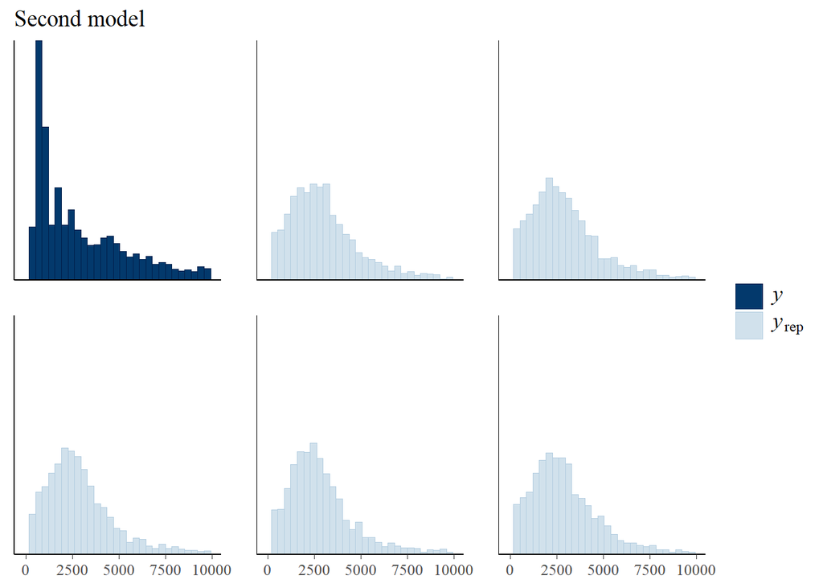

```r
ppc_hist(y, yrep2[1:5,]) + ggtitle("Second model") + xlim(-10^2, 10^4)
```

The last result confirm what we think from the beginning, the Bayesian t-Student Regression perform very bad for this analysis.

## Bayesian Gamma Regression

Considering we have a positive response, we can implement a Bayesian Gamma Regression, which we think can perform better than the others two models.

If:

$$Y_i|\mu_i, n_0 \sim Gamma (\mu_i\ n_0, n_0) \ \ \ \ \ \ \ \mathrm{
with}\ Y \in \ (0^+, \infty)$$

The model is:

$$h(\mu_i)=\beta_0+\beta_1x_\ +...+\beta_px_{ip}$$

Where $p$ is the number of predictors.

The regression coefficient may be given negative values, so we have to use a link function, in this case the link function of a gamma distribution is $h(\mu_i)=log(\mu_i)$.

Furthermore we know that:

$$E[Y_i|\mu_i,n_0] =\mu_i$$

Which is the mean of this distribution.

and:

$$Var[Y_i|\mu_i, n_0]=[\frac{\mu_in_0}{n_0^2}]= \frac{\mu_i}{n_0}$$

Where $n_0$ is a value which will decrease the variance.

```r
X3_train <- train %>%
  mutate(across(c(6:11), log, .names = "log_{.col}"), .keep = "unused") %>%
  mutate(across(c(1:2), log, .names = "log_{.col}"), .keep = "unused")
X3_train <- X3_train[c(1:9,11)]
X3_train <- model.matrix(log_price ~ ., data = X3_train)
```

### Metropolis-Hastings Algorithm

```r
p = ncol(X3_train)
n= nrow(X3_train)

model3_code <- function() {
  ## Likelihood
  for (i in 1:n) {
    y[i] ~ dgamma(mu[i]*n0, n0)
    log(mu[i]) <- X[i,] %*% b[]
  }
  ## Priors
  for (j in 1:p) {
    b[j] ~ dnorm(0, 0.01)
  }
  n0 ~ dgamma(0.1, 0.1)
}

model3_data <- list(y = y, X = X3_train, n = n, p = p)
model3_params <- c("b", "mu", "n0")

set.seed(123)

model3_run <- jags(
  data = model3_data,
  parameters.to.save = model3_params,
  model.file = model3_code,
  n.chains = 1,
  n.iter = 5000,
  n.burnin = 2000,
  n.thin = 1,
  jags.seed = 101
)
```

### Diagnostic

#### MCMC Traceplot

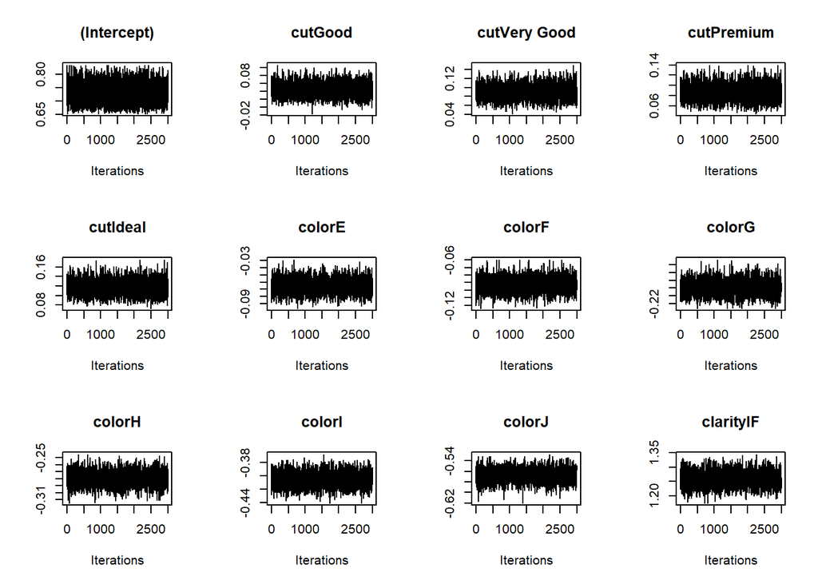

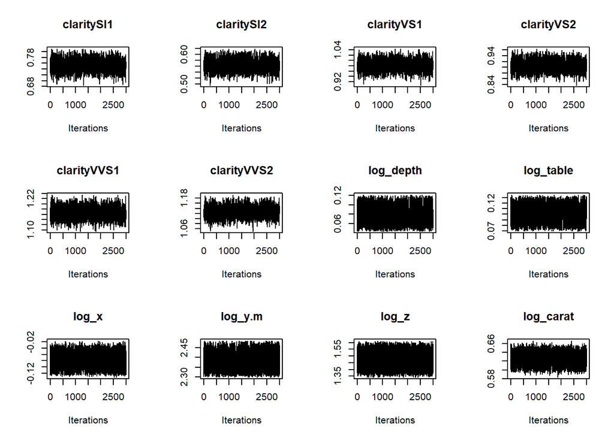

```r
par(mfrow=c(3, 4))
for(i in 1:p){
coda::traceplot(mcmc(model3_run$BUGSoutput$sims.list$b[,i]), main=colnames(X3_train)[i])
}
```

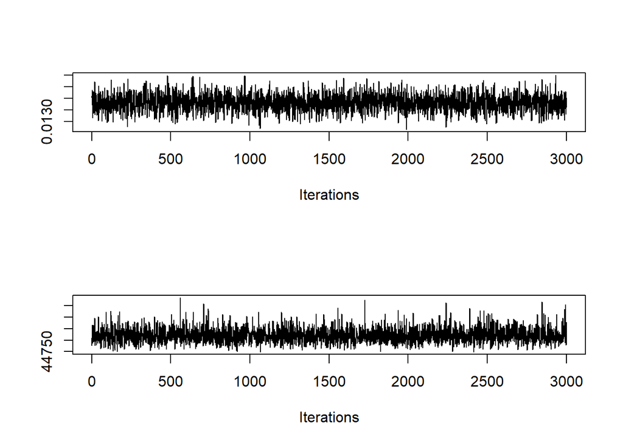

```r
par(mfrow=c(2,1))
traceplot(mcmc(model3_run$BUGSoutput$sims.list$n0))
traceplot(mcmc(model3_run$BUGSoutput$sims.list$deviance))
```

#### Auto-Correlation Plot

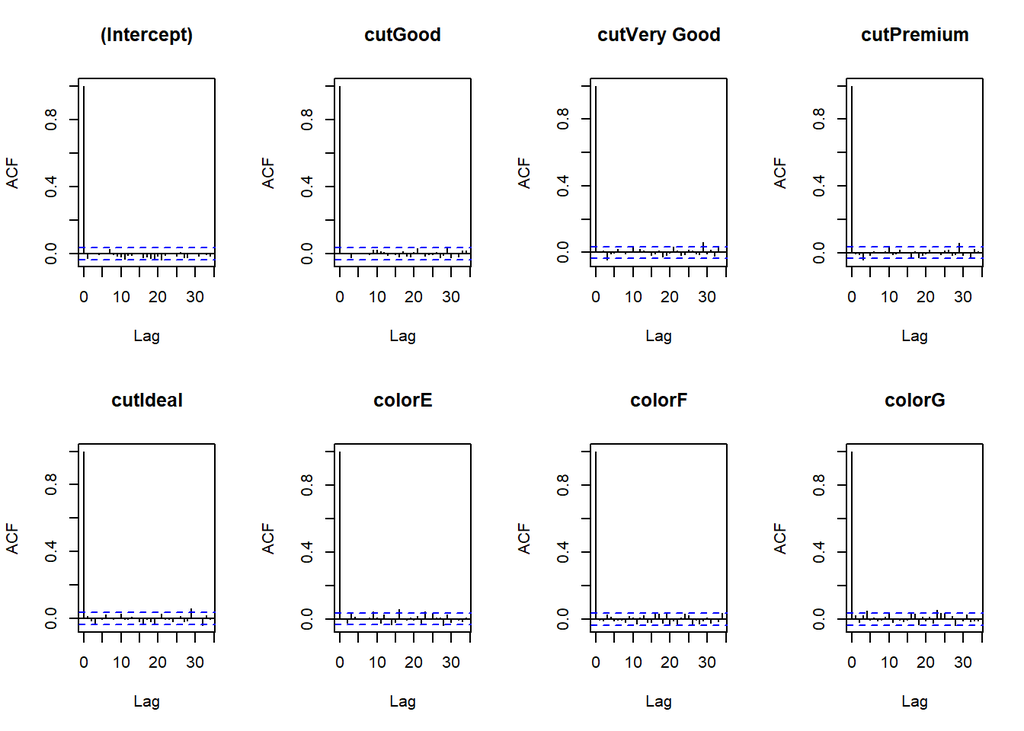

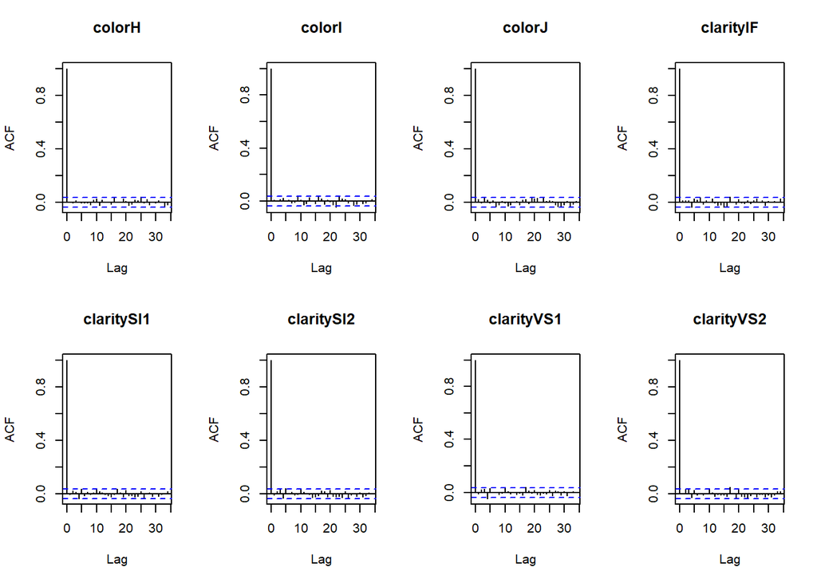

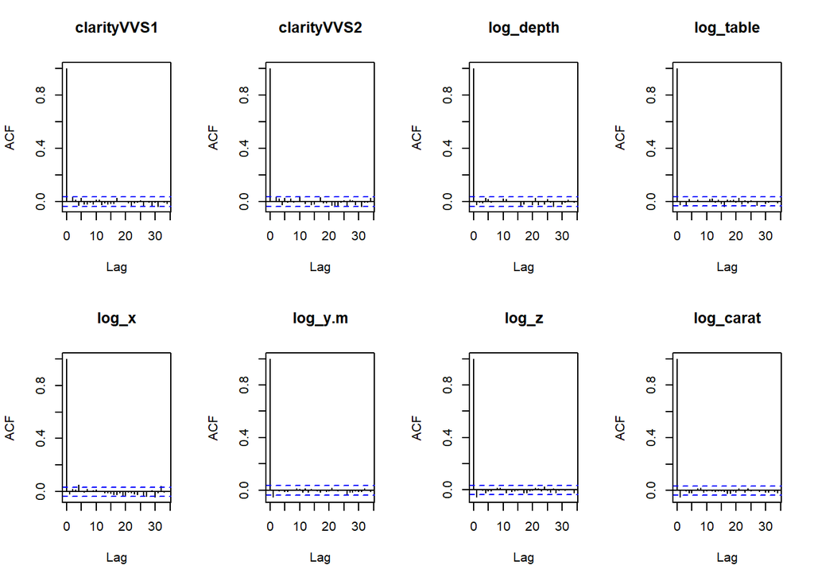

```r
par(mfrow=c(2,4))
for(i in 1:p){
acf(model3_run$BUGSoutput$sims.list$b[,i], main=colnames(X3_train)[i])
}
```

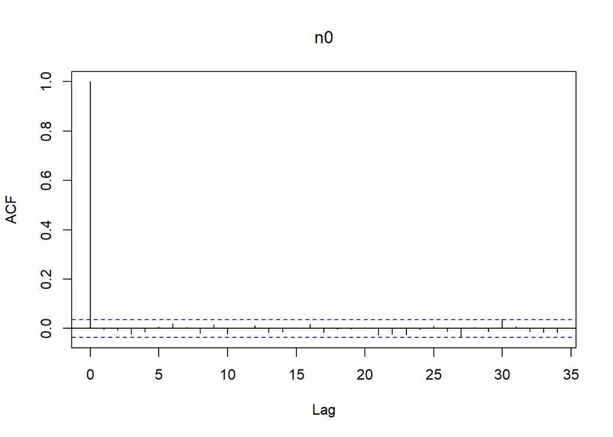

```r
acf(model3_run$BUGSoutput$sims.list$n0, main=expression(n0))
```

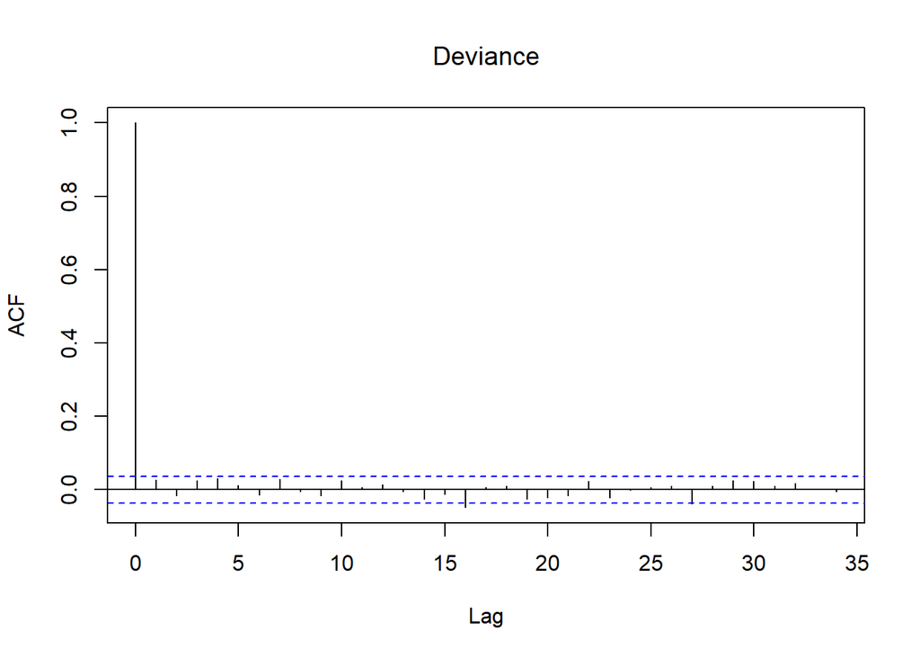

```r
acf(model3_run$BUGSoutput$sims.list$deviance, main=expression(Deviance))
```

#### Effective Sample Size

```r
for(i in 1:p){
  cat(colnames(X3_train)[i],": ",coda::effectiveSize(mcmc(model3_run$BUGSoutput$sims.list$b[,i])), sep="", end="\n")
}
```

```
## (Intercept): 3163.14
## cutGood: 3000
## cutVery Good: 3214.13
## cutPremium: 3000
## cutIdeal: 3000
## colorE: 3000
## colorF: 3000
## colorG: 2540.606
## colorH: 3000
## colorI: 3000
## colorJ: 3000
## clarityIF: 3000
## claritySI1: 2841.389
## claritySI2: 2656.586
## clarityVS1: 2855.949
## clarityVS2: 2609.59
## clarityVVS1: 2774.974
## clarityVVS2: 3000
## log_depth: 3000
## log_table: 3158.613
## log_x: 2593.545
## log_y.m: 3327.723
## log_z: 3342.368
## log_carat: 3306.218
```

```r
cat(colnames(X_train)[i],": ",coda::effectiveSize(mcmc(model3_run$BUGSoutput$sims.list$n0)))
```

```
## z :  3000
```

#### Geweke Test

```r
for(i in 1:p){
cat('Geweke test for ',colnames(X_train)[i],':',coda::geweke.diag(
model3_run$BUGSoutput$sims.list$b[,i])$z,end="\n")
}
```

```
## Geweke test for  (Intercept) : 0.6056155
## Geweke test for  carat : 0.2559008
## Geweke test for  cutGood : -0.08414923
## Geweke test for  cutVery Good : -0.485834
## Geweke test for  cutPremium : -0.02361099
## Geweke test for  cutIdeal : -1.017921
## Geweke test for  colorE : -1.098964
## Geweke test for  colorF : -1.474457
## Geweke test for  colorG : -1.417461
## Geweke test for  colorH : -1.536666
## Geweke test for  colorI : -1.269694
## Geweke test for  colorJ : 0.01349285
## Geweke test for  clarityIF : -0.04543351
## Geweke test for  claritySI1 : 0.0259663
## Geweke test for  claritySI2 : 0.100419
## Geweke test for  clarityVS1 : 0.04291253
## Geweke test for  clarityVS2 : 1.088134
## Geweke test for  clarityVVS1 : 0.1084472
## Geweke test for  clarityVVS2 : 2.111318
## Geweke test for  depth : -2.213097
## Geweke test for  table : -0.8331172
## Geweke test for  x : 1.688804
## Geweke test for  y.m : -1.555615
## Geweke test for  z : 1.909089
```

```r
cat('Geweke test for n0:',coda::geweke.diag(
model3_run$BUGSoutput$sims.list$n0)$z)
```

```
## Geweke test for n0: -0.4282726
```

## Parameters Analysis

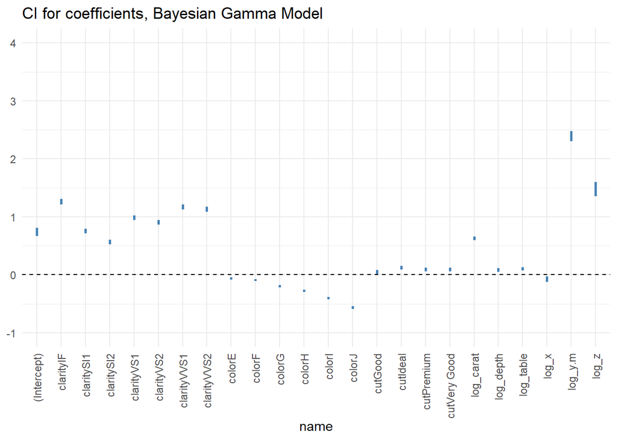

```r
b3_df <- as.data.frame(model3_run$BUGSoutput$sims.list$b)
names(b3_df) <- colnames(X3_train)
b3_long <- pivot_longer(b3_df, cols = 1:24) %>%
  group_by(name) %>%
  summarise(q025 = quantile(value, 0.025), q975 = quantile(value, 0.975)) %>%
  ungroup()

ggplot(b3_long, aes(x = name, ymin = q025, ymax = q975)) +
  geom_linerange(size = 1, color = "steelblue") + ylim(-1, 4) +
  geom_hline(yintercept = 0, linetype = 2) + theme_minimal() +
  theme(axis.text.x = element_text(angle = 90, vjust = 0.5, hjust=1)) +
  ggtitle("CI for coefficients, Bayesian Gamma Model")
```

### Significant Variables and Credible Intervals

```r
resu = as.matrix(colMeans(model3_run$BUGSoutput$sims.list$b),nrow=25)
resu = rbind(resu,colMeans(model3_run$BUGSoutput$sims.list$n0))
rownames(resu) = c(colnames(X3_train),"n0")
colnames(resu) = "Posterior Expectation"
res = t(apply(model3_run$BUGSoutput$sims.list$b,2,quantile,
prob=c(.025,.975)))
res = rbind(res,t(quantile(model3_run$BUGSoutput$sims.list$n0,
prob=c(.025,.975))))
rownames(res) = c(colnames(X3_train),"n0")
colnames(res) = c("2.5 % Quantile","97.5 % Quantile")
knitr::kable(cbind(res,resu), align = "lll")
```

|  | 2.5 % Quantile | 97.5 % Quantile | Posterior Expectation |
| --- | --- | --- | --- |
| (Intercept) | 0.6642219 | 0.8098201 | 0.7298232 |
| cutGood | 0.0120286 | 0.0820369 | 0.0448807 |
| cutVery Good | 0.0596691 | 0.1233259 | 0.0891581 |
| cutPremium | 0.0566946 | 0.1200438 | 0.0865740 |
| cutIdeal | 0.0881223 | 0.1515398 | 0.1177684 |
| colorE | -0.0842602 | -0.0448993 | -0.0650904 |
| colorF | -0.1120880 | -0.0739089 | -0.0928307 |
| colorG | -0.2172593 | -0.1797595 | -0.1994749 |
| colorH | -0.2994491 | -0.2590662 | -0.2800461 |
| colorI | -0.4261073 | -0.3835657 | -0.4059762 |
| colorJ | -0.5930453 | -0.5439710 | -0.5680548 |
| clarityIF | 1.2089003 | 1.3108427 | 1.2586436 |
| claritySI1 | 0.7128036 | 0.7940727 | 0.7515802 |
| claritySI2 | 0.5261384 | 0.6057952 | 0.5628522 |
| clarityVS1 | 0.9409111 | 1.0236809 | 0.9810276 |
| clarityVS2 | 0.8673453 | 0.9458321 | 0.9046974 |
| clarityVVS1 | 1.1221820 | 1.2121676 | 1.1655264 |
| clarityVVS2 | 1.0858931 | 1.1706673 | 1.1262680 |
| log_depth | 0.0459892 | 0.1169972 | 0.0715422 |
| log_table | 0.0732416 | 0.1307598 | 0.1056733 |
| log_x | -0.1235065 | -0.0299334 | -0.0714083 |
| log_y.m | 2.3058861 | 2.4756407 | 2.3911957 |
| log_z | 1.3558353 | 1.5981882 | 1.4656791 |
| log_carat | 0.5961292 | 0.6552156 | 0.6256332 |
| n0 | 0.0131058 | 0.0145172 | 0.0138246 |

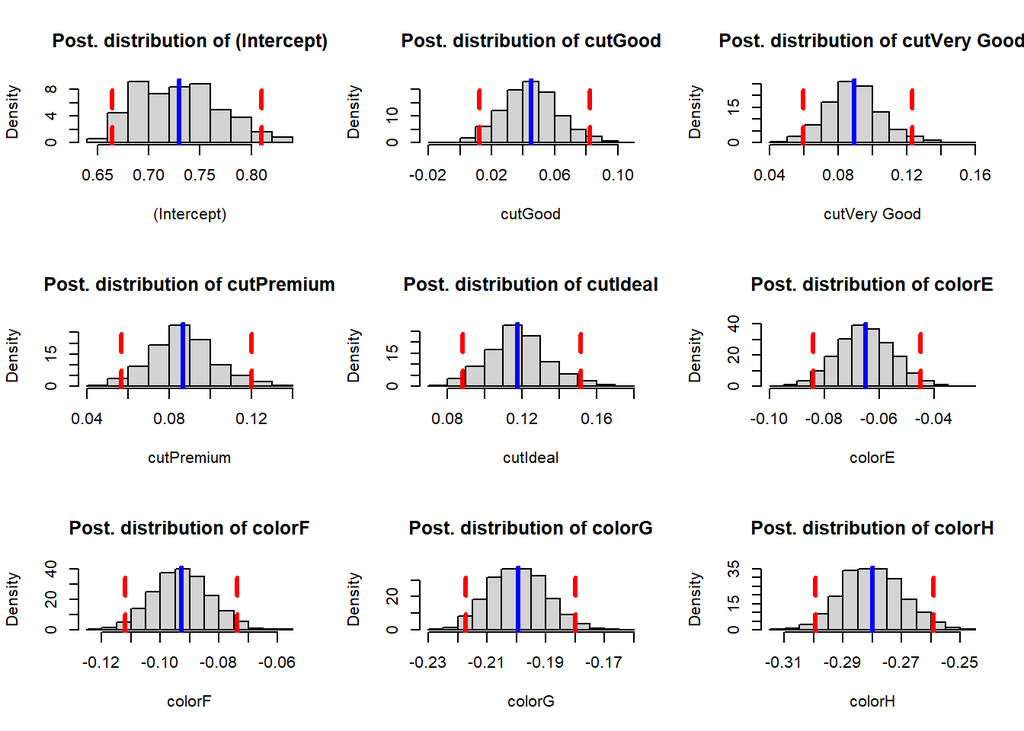

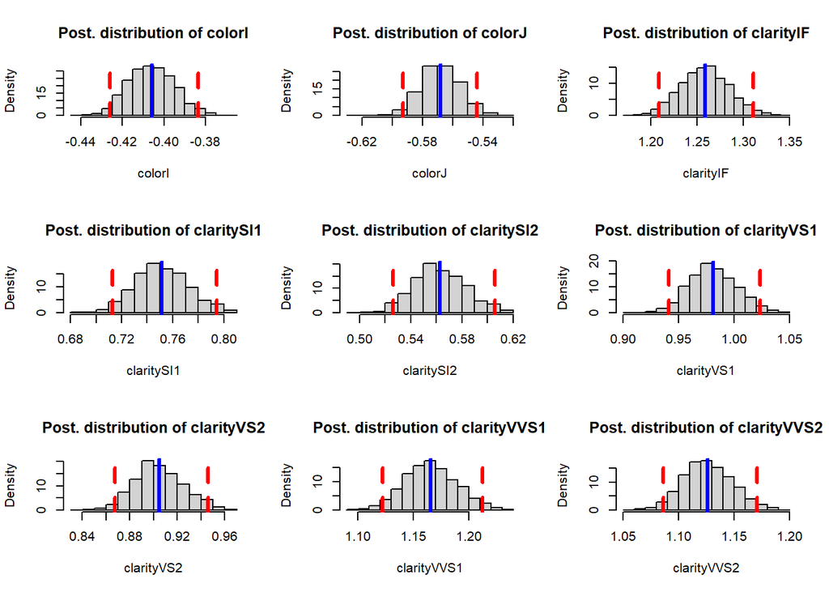

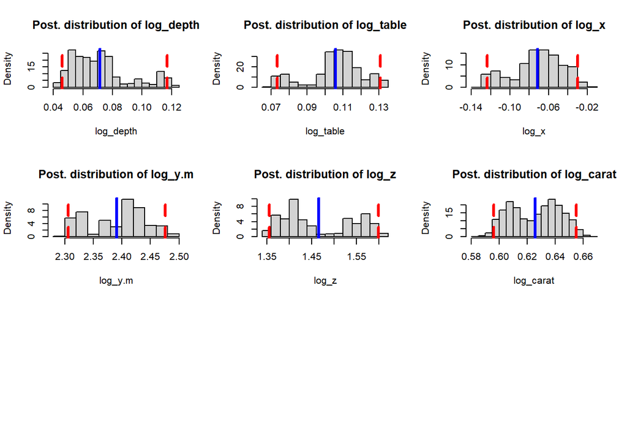

```r
par(mfrow=c(3,3))
for(i in 1:24){
hist(model3_run$BUGSoutput$sims.list$b[,i],
main=paste("Post. distribution of", rownames(res)[i]),
xlab = rownames(res)[i],cex=0.8, prob = TRUE)
abline(v=res[i,1], col="red",lty=2, lwd=3)
abline(v=res[i,2], col="red",lty=2, lwd=3)
abline(v=resu[i,1], col="blue", lwd=3)
}
```

### Posterior Predictive Model Checking

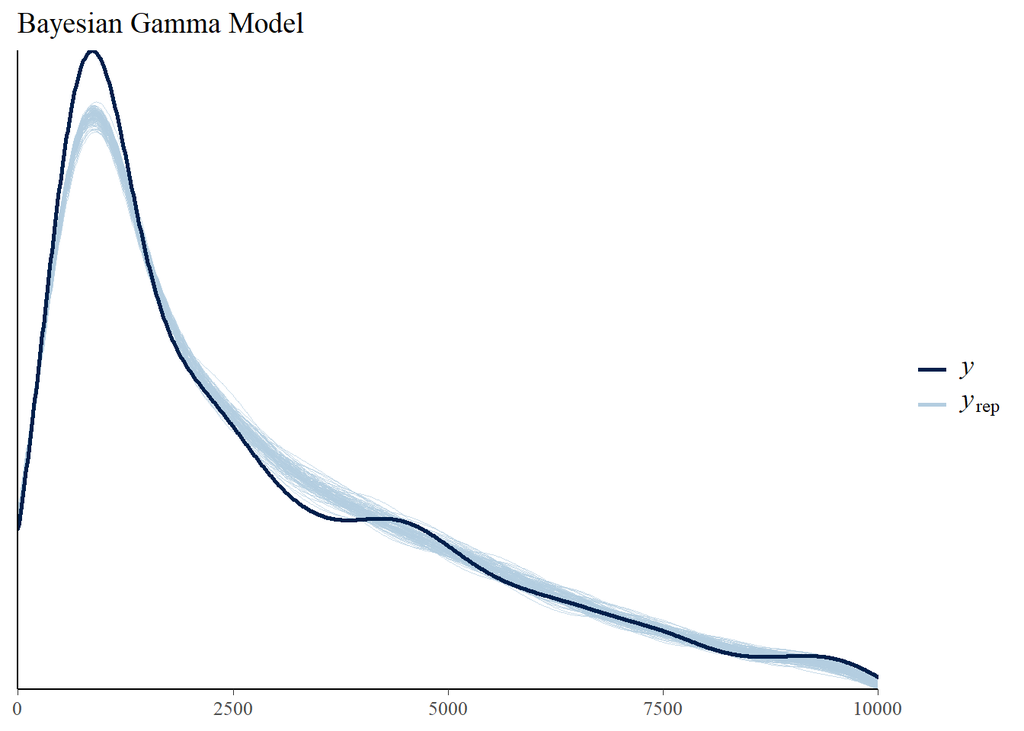

```r
mu3 <- model3_run$BUGSoutput$sims.list$mu
n03 <- model3_run$BUGSoutput$sims.list$n0
yrep3 <- t(sapply(1:100, function(i) rgamma(n, mu3[i,]*n03[i], n03[i])))

ppc_dens_overlay(y, yrep3) + ggtitle("Bayesian Gamma Model ") + xlim(0, 10^4)
```

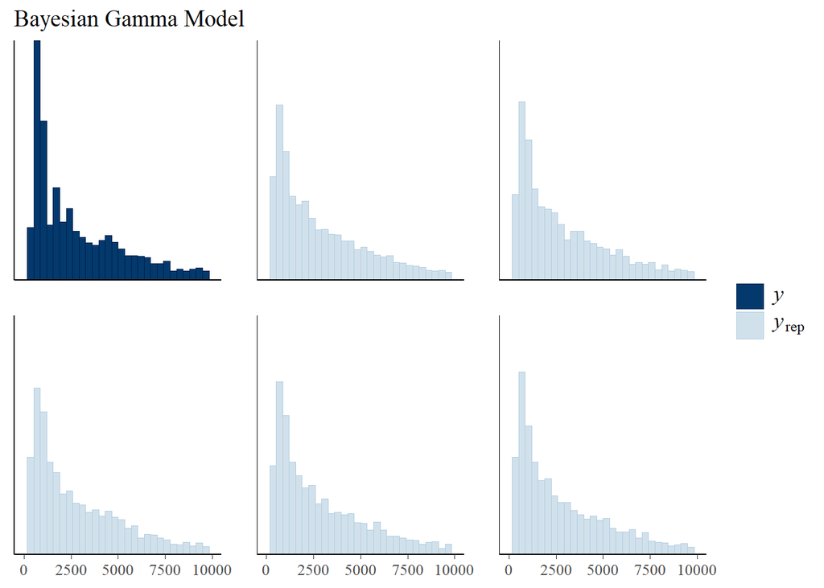

```r
ppc_hist(y, yrep3[1:5,]) + ggtitle("Bayesian Gamma Model ") + xlim(0, 10^4)
```

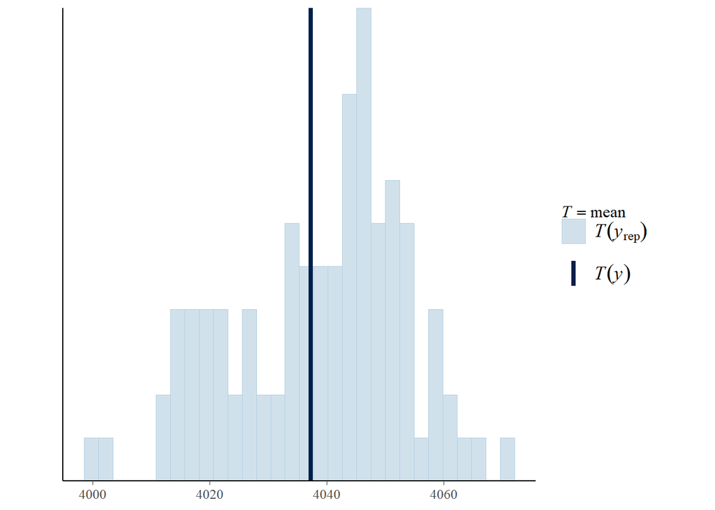

```r
ppc_stat(y, yrep3, stat = mean) + theme(aspect.ratio = 1)
```

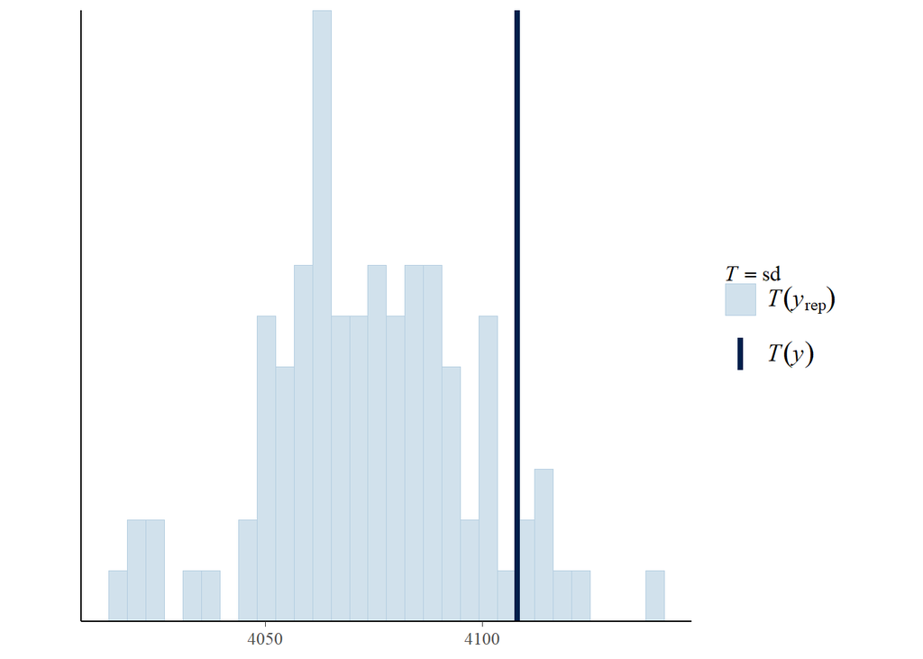

```r
ppc_stat(y, yrep3, stat = sd) + theme(aspect.ratio = 1)
```

## Variable Selection

We implement the Spike and Slap method assigning the following distributions:

- $\gamma_j \sim Ber(w)$
- The joint Spike and Slab: $p(\beta_j,\gamma_j)=(1-w)\delta_o+w\ d\mathcal{N}(\beta_j|0,0.01)$
- Prior: $w\sim Beta(1,1)$

```r
model4_code <- function() {
  ## Likelihood
  for (i in 1:n) {
    y[i] ~ dgamma(mu[i]*n0, n0)
    log(mu[i]) <- (phi*b)%*%X[i,]
  }
  #Model
  for(j in 1:p){
  phi[j] ~ dbern(w)
  }
  ## Priors
  for (j in 1:p) {
    b[j] ~ dnorm(0, 0.01)
  }
  n0 ~ dgamma(0.1, 0.1)
  w ~ dbeta(1, 1)
}

model4_data <- list(y = y, X = X3_train, n = n, p = p)
model4_params <- c("b", "mu", "n0", "w", "phi")

model4_run <- jags(
  data = model4_data,
  parameters.to.save = model4_params,
  model.file = model4_code,
  n.chains = 1,
  n.iter = 5000,
  n.burnin = 2000,
  n.thin = 1,
  jags.seed = 101
)
```

### MCMC Traceplot

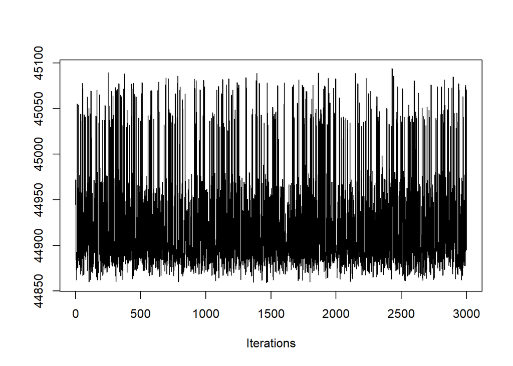

```r
traceplot(mcmc(model4_run$BUGSoutput$sims.list$deviance))
```

Now we can use the frequency of $\gamma_j^{(s)}=1$ to compute the probability of inclusion of the $j^{th}$ predictor: $\hat p_j=\frac{1}{S}\sum^S_{s=1}=\phi_j^{(s)}$

This represents the percentage of times across the S models that a predictor is included in the model.

```r
out <- model4_run$BUGSoutput
prob.inclusion <- colMeans(out$sims.list$phi)
names(prob.inclusion) <- rownames(res)[1:24]
prob.inclusion <- (as.matrix(prob.inclusion))
colnames(prob.inclusion) <- "Probability of inclusion"
knitr::kable(prob.inclusion)
```

|  | Probability of inclusion |
| --- | --- |
| (Intercept) | 0.0093333 |
| cutGood | 0.7053333 |
| cutVery Good | 0.8960000 |
| cutPremium | 0.9643333 |
| cutIdeal | 1.0000000 |
| colorE | 1.0000000 |
| colorF | 1.0000000 |
| colorG | 1.0000000 |
| colorH | 1.0000000 |
| colorI | 1.0000000 |
| colorJ | 1.0000000 |
| clarityIF | 1.0000000 |
| claritySI1 | 1.0000000 |
| claritySI2 | 1.0000000 |
| clarityVS1 | 1.0000000 |
| clarityVS2 | 1.0000000 |
| clarityVVS1 | 1.0000000 |
| clarityVVS2 | 1.0000000 |
| log_depth | 0.0000000 |
| log_table | 0.0500000 |
| log_x | 0.0620000 |
| log_y.m | 1.0000000 |
| log_z | 1.0000000 |
| log_carat | 1.0000000 |

## Bayesian Gamma Regression with Variable Selection

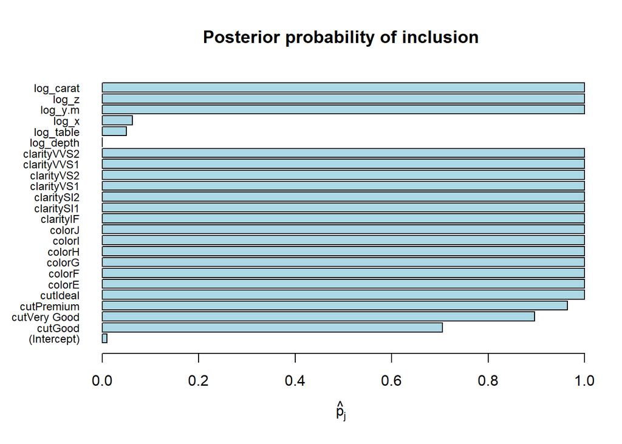

```r
par(mfrow = c(1,1), mar=c(5.1, 5.5, 4.1, 2.1))
prob.inclusion <- colMeans(out$sims.list$phi)
names(prob.inclusion) <- rownames(res)[1:24]
barplot(prob.inclusion, col = "lightblue",
xlab = expression(hat(p)[j]),
cex.names=0.75,las=1, horiz=T, main="Posterior probability of inclusion")
```

```r
model_phi<- model4_run$BUGSoutput$sims.list$phi
colnames(model_phi) <- c(colnames(X3_train))

model_MPM <- as.numeric(colMeans(model_phi) >= 0.5)
names(model_MPM) <- c(colnames(X3_train))
knitr::kable(model_MPM)
```

|  | x |
| --- | --- |
| (Intercept) | 0 |
| cutGood | 1 |
| cutVery Good | 1 |
| cutPremium | 1 |
| cutIdeal | 1 |
| colorE | 1 |
| colorF | 1 |
| colorG | 1 |
| colorH | 1 |
| colorI | 1 |
| colorJ | 1 |
| clarityIF | 1 |
| claritySI1 | 1 |
| claritySI2 | 1 |
| clarityVS1 | 1 |
| clarityVS2 | 1 |
| clarityVVS1 | 1 |
| clarityVVS2 | 1 |
| log_depth | 0 |
| log_table | 0 |
| log_x | 0 |
| log_y.m | 1 |
| log_z | 1 |
| log_carat | 1 |

```r
model_MPM[1] <- 1  # Include the intercept
X_MPM <- X3_train[,as.logical(model_MPM)]

MPM_data <- list(y = y, X = X_MPM, n = n, p = ncol(X_MPM))

MPM_run <- jags(
  data = MPM_data,
  parameters.to.save = model3_params,
  model.file = model3_code,
  n.chains = 1,
  n.iter = 5000,
  n.burnin = 2000,
  n.thin = 1,
  jags.seed = 101
)
```

### Diagnostic

#### MCMC Trace-plot

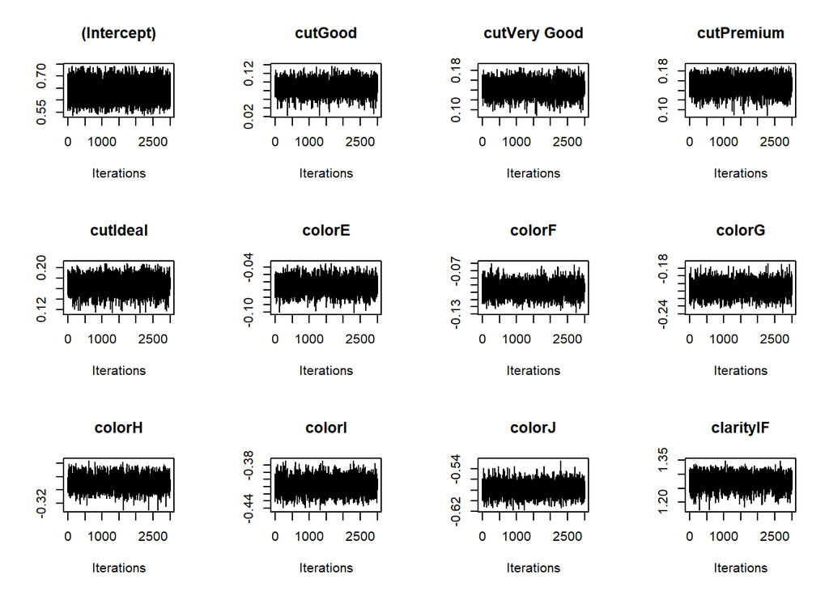

```r
p2 = ncol(X_MPM)

par(mfrow=c(3, 4))
for(i in 1:p2){
coda::traceplot(mcmc(MPM_run$BUGSoutput$sims.list$b[,i]), main=colnames(X_MPM)[i])
}
```

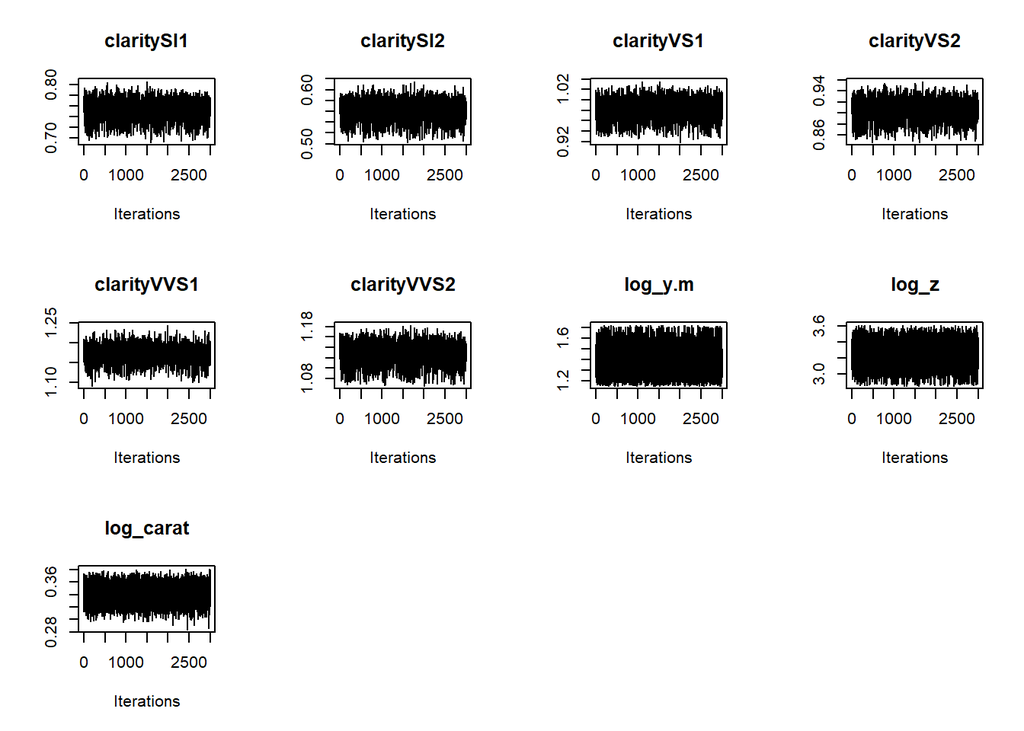

```r
par(mfrow=c(2,1))
```

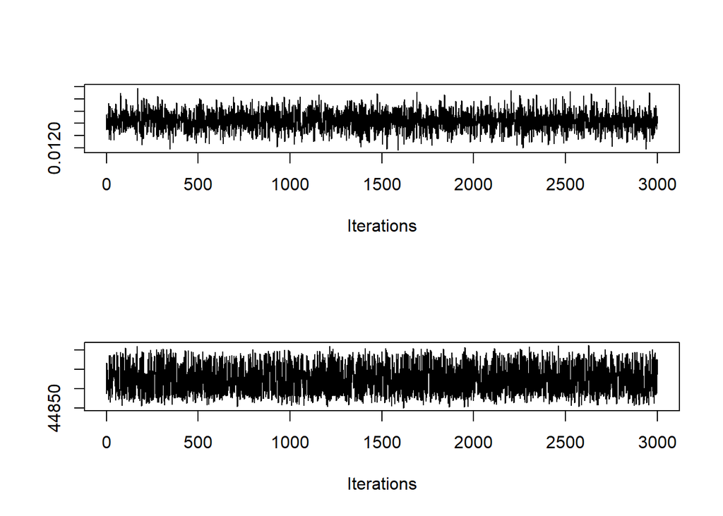

```r
traceplot(mcmc(MPM_run$BUGSoutput$sims.list$n0))
traceplot(mcmc(MPM_run$BUGSoutput$sims.list$deviance))
```

#### Auto-Correlation Plot

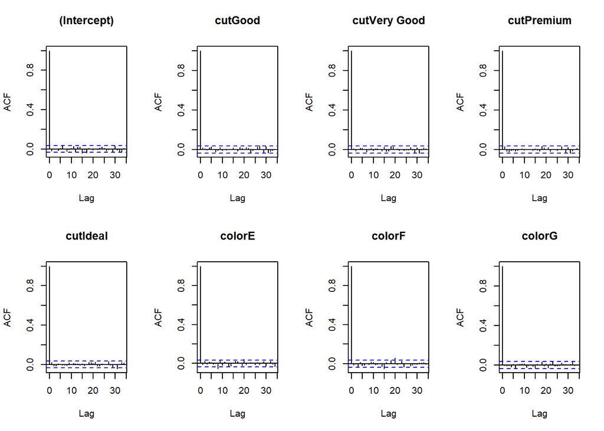

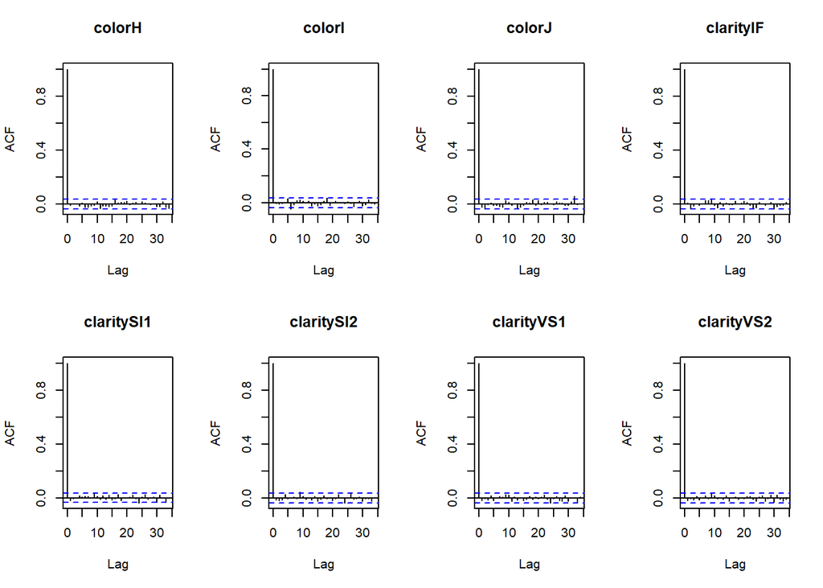

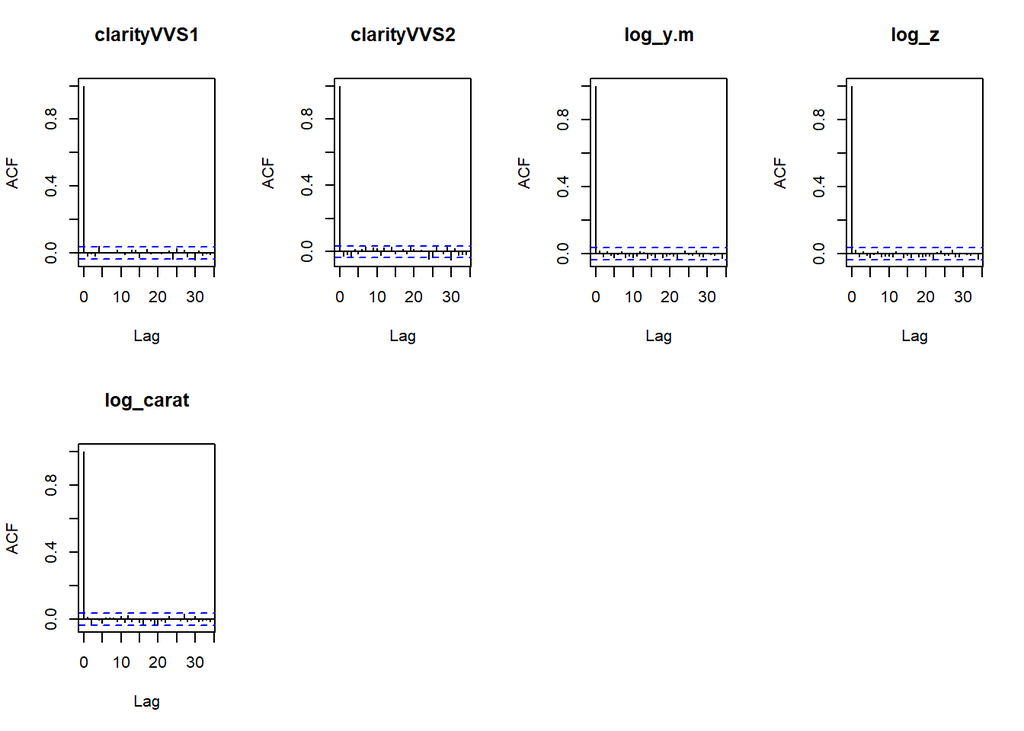

```r
par(mfrow=c(2,4))
for(i in 1:p2){
acf(MPM_run$BUGSoutput$sims.list$b[,i], main=colnames(X_MPM)[i])
}
```

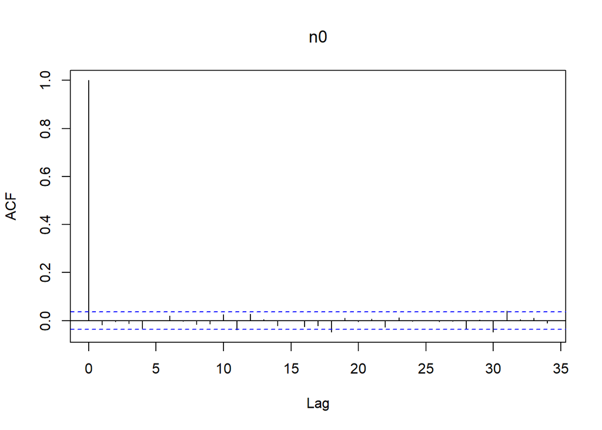

```r
acf(MPM_run$BUGSoutput$sims.list$n0, main=expression(n0))
```

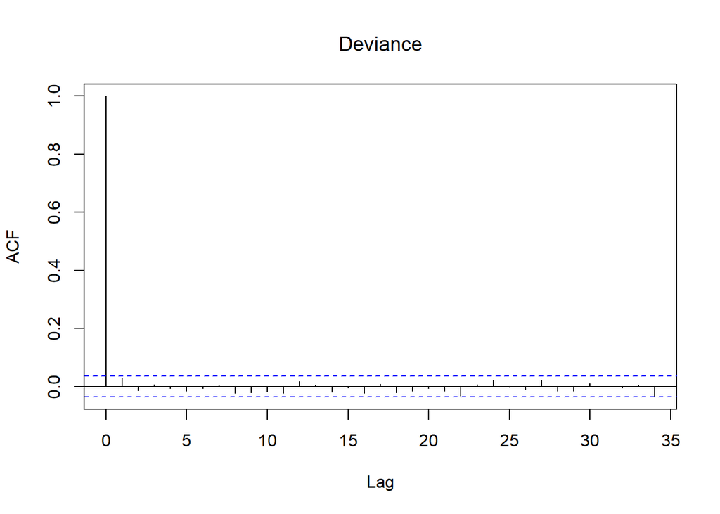

```r
acf(MPM_run$BUGSoutput$sims.list$deviance, main=expression(Deviance))
```

#### Effective Sample Size

```r
for(i in 1:17){
  cat(colnames(X_MPM)[i],": ",coda::effectiveSize(mcmc(MPM_run$BUGSoutput$sims.list$b[,i])), sep="", end="\n")
}
```

```
## (Intercept): 3000
## cutGood: 3000
## cutVery Good: 3000
## cutPremium: 2815.56
## cutIdeal: 3000
## colorE: 3000
## colorF: 3000
## colorG: 3000
## colorH: 3000
## colorI: 3000
## colorJ: 3343.785
## clarityIF: 3000
## claritySI1: 3000
## claritySI2: 3000
## clarityVS1: 3000
## clarityVS2: 3000
## clarityVVS1: 3000
```

```r
cat(colnames(X_train)[i],": ",coda::effectiveSize(mcmc(MPM_run$BUGSoutput$sims.list$n0)))
```

```
## clarityVS2 :  3000
```

#### Geweke Test

```r
for(i in 1:17){
cat('Geweke test for ',colnames(X_MPM)[i],':',coda::geweke.diag(
MPM_run$BUGSoutput$sims.list$b[,i])$z,end="\n")
}
```

```
## Geweke test for  (Intercept) : 0.675597
## Geweke test for  cutGood : -0.8983502
## Geweke test for  cutVery Good : -0.471252
## Geweke test for  cutPremium : -0.5065005
## Geweke test for  cutIdeal : -0.5800409
## Geweke test for  colorE : -0.1792375
## Geweke test for  colorF : -0.5790263
## Geweke test for  colorG : 0.02502096
## Geweke test for  colorH : 0.7042209
## Geweke test for  colorI : -0.6429407
## Geweke test for  colorJ : -0.4822453
## Geweke test for  clarityIF : 0.2358405
## Geweke test for  claritySI1 : 0.02531845
## Geweke test for  claritySI2 : -0.07283527
## Geweke test for  clarityVS1 : -0.2048473
## Geweke test for  clarityVS2 : -0.1972105
## Geweke test for  clarityVVS1 : 0.4530894
```

```r
cat('Geweke test for n0:',coda::geweke.diag(
MPM_run$BUGSoutput$sims.list$n0)$z)
```

```
## Geweke test for n0: 2.435891
```

## Parameters Analysis

### Significant Variables and Credible Intervals

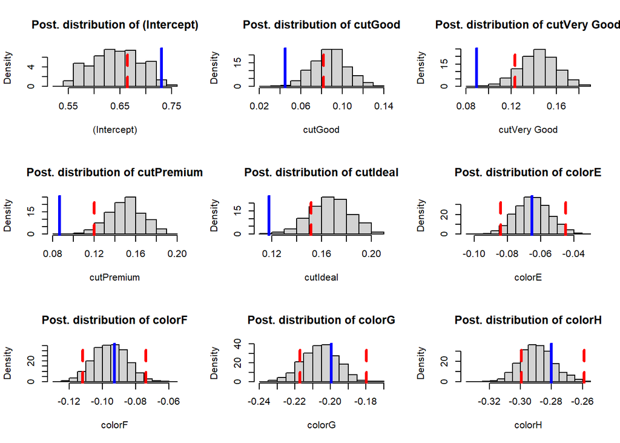

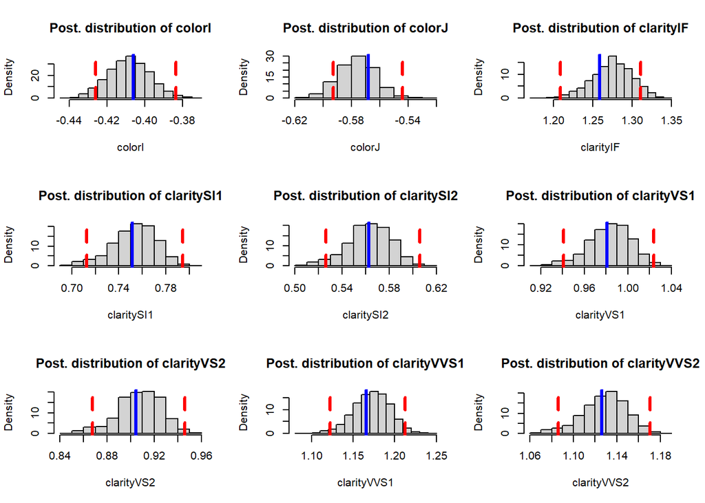

[figure not shown]

```r
par(mfrow=c(3,3))
for(i in 1:p2){
hist(MPM_run$BUGSoutput$sims.list$b[,i],
main=paste("Post. distribution of", rownames(res)[i]),
xlab = rownames(res)[i],cex=0.8, prob = TRUE)
abline(v=res[i,1], col="red",lty=2, lwd=3)
abline(v=res[i,2], col="red",lty=2, lwd=3)
abline(v=resu[i,1], col="blue", lwd=3)
}
```

### Posteriori Predictive Model Checking

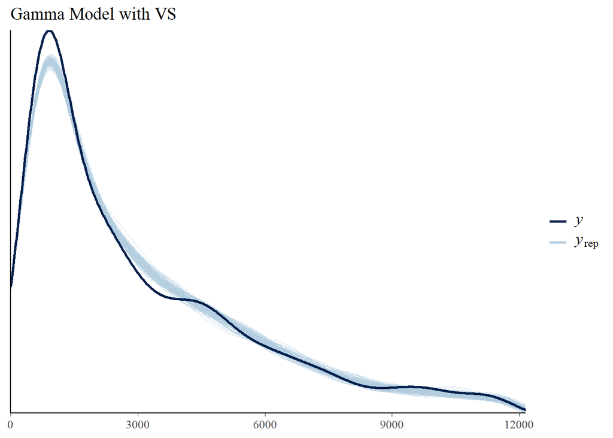

```r
mu4 <- MPM_run$BUGSoutput$sims.list$mu
n04 <- MPM_run$BUGSoutput$sims.list$n0
yrep4 <- t(sapply(1:100, function(i) rgamma(n, mu4[i,]*n04[i], n04[i])))

ppc_dens_overlay(y, yrep4) + ggtitle("Gamma Model with VS ") + xlim(0, 10.5^4)
```

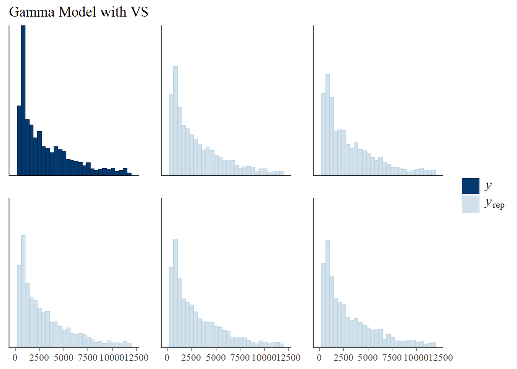

```r
ppc_hist(y, yrep4[1:5,]) + ggtitle("Gamma Model with VS") + xlim(0, 10.5^4)
```

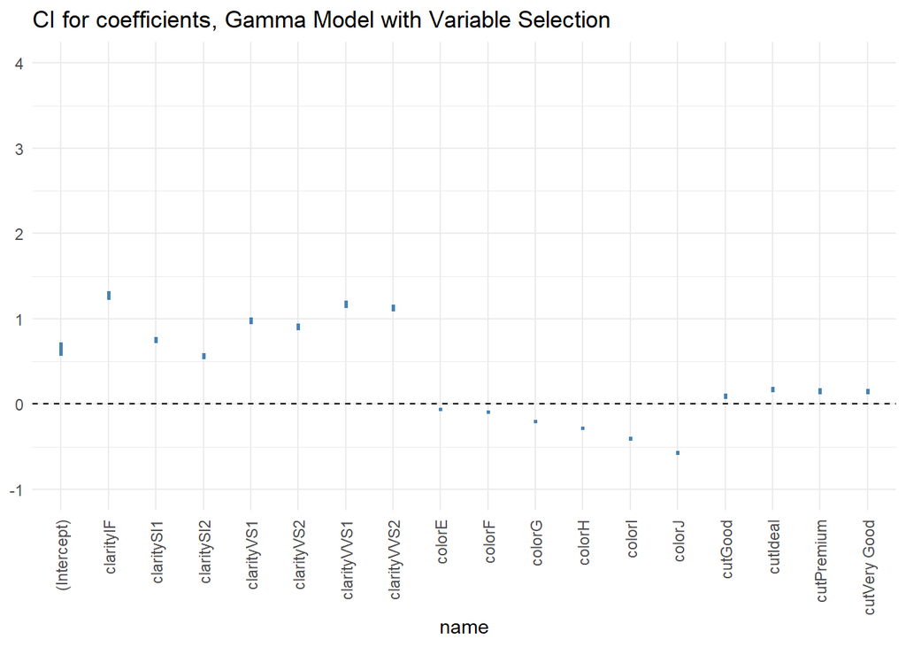

```r
b4_df <- as.data.frame(MPM_run$BUGSoutput$sims.list$b)
names(b4_df) <- colnames(X_MPM)
b4_long <- pivot_longer(b4_df, cols = 1:18) %>%
  group_by(name) %>%
  summarise(q025 = quantile(value, 0.025), q975 = quantile(value, 0.975)) %>%
  ungroup()

ggplot(b4_long, aes(x = name, ymin = q025, ymax = q975)) +
  geom_linerange(size = 1, color = "steelblue") + ylim(-1, 4) +
  geom_hline(yintercept = 0, linetype = 2) + theme_minimal() +
  theme(axis.text.x = element_text(angle = 90, vjust = 0.5, hjust=1)) +
  ggtitle("CI for coefficients, Gamma Model with Variable Selection ")
```

# Compare models using DIC and MSE

## Deviance Information Criterion (DIC)

Deviance can be defined:

$$D(\theta)=-2log\ p(Y|\theta) + C$$

where:

$p(Y|\theta)$is the likelihood of the data;

$C$ is a constant.

This is basically the likelihood, so model with high likelihood will have a better fit, if we take the log we have a measure we should minimize and moreover it is very naturally to compute. This at each iteration of our model.

$$\bar D(\theta) = \frac{1}{G} \sum^G_{g=1}D(\theta_g)$$

This can be a good measure of fitting.

An information criterion, such the AIC and BIC, as a measure of model complexity:

$$p_D=\bar D(\theta) - D(\hat\theta)$$

where $E(\hat\theta|Y_{obs})$

The $p_D$ can be written as:

$$\frac{1}{2}\hat{Var}(D(\theta))=\frac{1}{2}\frac{1}{G-1}\sum_{g=1}^G(D(\theta_g)-\bar{D}(\theta))^2$$

This is a measure of how the deviance change at each iteration with the respect of the mean.

This is affected by the number of parameters.

At the end the DIC is:

$$DIC=\bar D+p_D$$

```r
knitr::kable(cbind(model1_run$BUGSoutput$DIC,model2_run$BUGSoutput$DIC, model3_run$BUGSoutput$DIC, MPM_run$BUGSoutput$DIC), col.names = c("Normal Model", "t-student model","Gamma Model", "Gamma Model with VS"), align = "ccc")
```

| Normal Model | t-student model | Gamma Model | Gamma Model with VS |
| --- | --- | --- | --- |
| 58446.36 | 58082.73 | 44784.31 | 45672.73 |

## Mean Square Error (MSE)

Defined as:

$$E[(Y-\hat Y) ^2]$$

This can be defined as:

$$\frac{1}{n}\sum^n_{i=1}(Y_i-\hat Y)^2$$

$Y_i$ are from the test-set.

We want to minimize this loss-function.

$$\hat Y=E[Y^*|Y_{1:n}]$$

```r
# For Normal Model and t-student
y_test <- test$price

X_test <- test[, c(2, 3, 4, 5, 6, 7, 9, 10, 11)]

X_test <- model.matrix(y_test~. , data=X_test)


# For Gamma Model
X3_test <- test %>%
  mutate(across(c(6:11), log, .names = "log_{.col}"), .keep = "unused") %>%
  mutate(across(c(1:2), log, .names = "log_{.col}"), .keep = "unused")
X3_test <- X3_test[c(1:9,11)]
X3_test <- model.matrix(log_price ~ ., data = X3_test)

## For Gamma Model with Variable Selection

X4_test <- X3_test[,as.logical(model_MPM)]

mu1_pred <- as.matrix(b1_df)%*%t(X_test)
sd1_pred <- sqrt(1/tau1)
ypred1 <- sapply(1:3000, function(i) rnorm(n, mu1_pred[i,], sd1_pred[i]))
ypred1_means <- apply(ypred1, 1, mean)

MSE1 <- mean((y_test - ypred1_means)^2)
RMSE1 <- sqrt(MSE1)

mu2_pred <- as.matrix(b2_df)%*%t(X_test)
sd2_pred <- sqrt(1/tau2)
k2_pred <- k2
ypred2 <- sapply(1:3000, function(i) mu2_pred[i,] + sd2_pred[i]*rt(n, df = k2[i]))
ypred2_means <- apply(ypred2, 1, mean)

MSE2 <- mean((y_test - ypred2_means)^2)
RMSE2 <- sqrt(MSE2)


mu3_pred <- exp(as.matrix(b3_df)%*%t(X3_test))
n03_pred <- n03
ypred3 <- sapply(1:3000, function(i) rgamma(n, mu3_pred[i,]*n03[i], n03[i]))
ypred3_means <- apply(ypred3, 1, mean)

MSE3 <- mean((y_test - ypred3_means)^2)
RMSE3 <- sqrt(MSE3)

mu4_pred <- exp(as.matrix(b4_df)%*%t(X4_test))
n04_pred <- n04
ypred4 <- sapply(1:3000, function(i) rgamma(n, mu4_pred[i,]*n04[i], n04[i]))
ypred4_means <- apply(ypred4, 1, mean)

MSE4 <- mean((y_test - ypred4_means)^2)
RMSE4 <- sqrt(MSE4)

knitr::kable(t(c(RMSE1, RMSE2, RMSE3, RMSE4)),align = "cccc", "pipe", col.names = c("B. Linear Model","B. t-student model","B. Gamma model","B. Gamma model with VS"))
```

| B. Linear Model | B. t-student model | B. Gamma model | B. Gamma model with VS |
| --- | --- | --- | --- |
| 3764.281 | 4138.265 | 655.7439 | 702.7845 |

# Prior Sensitivity Analysis

Due to the number of observations that we consider for the train set, a change of the hyper-parameters of the priors for each model would not change the credible intervals of the coefficients.

To see changes in the posterior, it would be necessary to implement a very strong prior. One possible prior of this type could be a t-Student with k degrees of freedom that go to infinity.

# Conclusion

Finally, after all the anlysis performed we can state that the Bayesian Gamma Model is the most precise among the others models,, in predicting, which was the goal of this analysis.